# Prediction Assignment Writeup

Dong Liang

May 16, 2016

# Prediciotn of activity patterns using a random forest model

```r
## Load up packages -------------------------------------------------------------------
library(caret)
library(ggplot2)
library(magrittr)
library(data.table)
library(dplyr)
library(doMC)
library(DescTools)
```

## Background

The report is generated to identify patterns of activities when people perfom excercises. The data used were collected from accelerometers on the belt, forearm, arm, and dumbell of 6 participants.

In the experiment, the 6 participants were asked to perform unilateral dumbbell biceps curl in five different fashions: exactly according to the specification (Class A), throwing the elbows to the front (Class B), lifting the dumbbell only halfway (Class C), lowering the dumbbell only halfway (Class D) and throwing the hips to the front (Class E). The human activity recognition device recoded data from accelerometers on the belt, forearm, arm, and dumbell.

Read more: http://groupware.les.inf.puc-rio.br/har#ixzz49bb9umaP

## Data Acquisition

In order to predict the pattern of acitvities when the particpants did the exercise, a random forest model has been constructed using training dataset. The train and test datasets are downloade directly from the weblink as follows: [Training](https://d396qusza40orc.cloudfront.net/predmachlearn/pml-training.csv), Testing.

```r
## Load up train and test datasets -------------------------------------------------------------------
train = read.csv("https://d396qusza40orc.cloudfront.net/predmachlearn/pml-training.csv")
test = read.csv("https://d396qusza40orc.cloudfront.net/predmachlearn/pml-testing.csv")
```

## Data Cleaning and Preprocessing

```r
# Find the variable columes that contain more that 80% NAs or empty values. Those data may probably not be useful for modeling due to the limited info provided.
setDT(train)
setDT(test)
na_gt_80perc = train[, lapply(.SD, function(c) ((is.na(c) | c == "" ) %>% sum)/length(c)) > 0.8]

# Remove the index variable - X, outcome varaible(Y) - classe and the problem id - problem_id from train and test datasets
tr_x = train[, c(!na_gt_80perc), with = F] %>% select(-classe, -X)
te_x = test[, c(!na_gt_80perc), with = F] %>% select(-problem_id, -X)
tr_Y = train[, c(!na_gt_80perc), with = F]$classe
```

The original train dataset has 160 variables, but unfortunately, not all of the features recorded are useful for building a random forest model due to the high percentatge of NA and empty values. Besides, the index varaible- X and outcome variable - classe should also be excluded from predictor features. After clearning up, I keep the following features: *user_name, raw_timestamp_part_1, raw_timestamp_part_2, cvtd_timestamp, new_window, num_window, roll_belt, pitch_belt, yaw_belt, total_accel_belt, gyros_belt_x, gyros_belt_y, gyros_belt_z, accel_belt_x, accel_belt_y, accel_belt_z, magnet_belt_x, magnet_belt_y, magnet_belt_z, roll_arm, pitch_arm, yaw_arm, total_accel_arm, gyros_arm_x, gyros_arm_y, gyros_arm_z, accel_arm_x, accel_arm_y, accel_arm_z, magnet_arm_x, magnet_arm_y, magnet_arm_z, roll_dumbbell, pitch_dumbbell, yaw_dumbbell, total_accel_dumbbell, gyros_dumbbell_x, gyros_dumbbell_y, gyros_dumbbell_z, accel_dumbbell_x, accel_dumbbell_y, accel_dumbbell_z, magnet_dumbbell_x, magnet_dumbbell_y, magnet_dumbbell_z, roll_forearm, pitch_forearm, yaw_forearm, total_accel_forearm, gyros_forearm_x, gyros_forearm_y, gyros_forearm_z, accel_forearm_x, accel_forearm_y, accel_forearm_z, magnet_forearm_x, magnet_forearm_y, magnet_forearm_z*

## Train a random forest model

I first use the trimmed train dataset and further split it into sub_train and sub_test using the `createDataPartition` function in the caret package. The sub_train dataset is used to train a random forest model with 5 fold cross validation.

```r
# Data preperation
intrain = createDataPartition(train$X, p = .75) %>% unlist
sub_train_x = tr_x[intrain,]
sub_train_Y = tr_Y[intrain]
sub_test_x = tr_x[-intrain, ]
sub_test_Y = tr_Y[-intrain]

# register multi-cores using DoMC package
registerDoMC(cores = detectCores() - 1)

# Train a random forest model
trCtl = trainControl(method = "cv", number = 5, allowParallel = T)
# mod = train(sub_train_x, sub_train_Y, method = 'rf', trControl = trCtl )
```

## Model interpretation

The variable importance is shown

```r
varImp(mod)
```

```
rf variable importance

  only 20 most important variables shown (out of 58)

                     Overall
cvtd_timestamp       100.000
raw_timestamp_part_1  71.433
roll_belt             32.437
num_window            32.231
magnet_dumbbell_y     15.722
pitch_belt            13.390
magnet_dumbbell_x     11.914
yaw_belt              10.727
magnet_dumbbell_z     10.585
pitch_forearm         10.046
roll_dumbbell          8.993
roll_forearm           8.667
accel_forearm_x        7.487
magnet_belt_y          7.243
magnet_belt_z          6.638
accel_dumbbell_y       5.979
accel_belt_z           5.101
total_accel_dumbbell   3.676
accel_dumbbell_z       2.958
magnet_belt_x          2.458
```

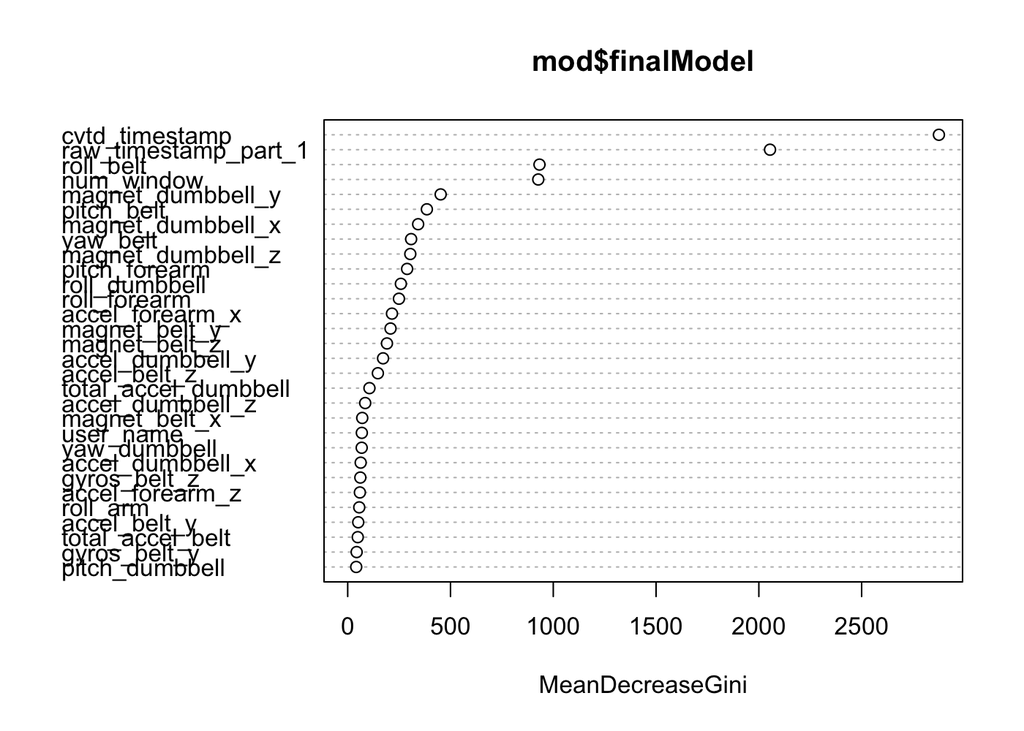

```r
varImpPlot(mod$finalModel, type = 2)
```

```r
mod$finalModel$importance
```

```
                     MeanDecreaseGini
user_name                6.869032e+01
raw_timestamp_part_1     2.054350e+03
raw_timestamp_part_2     4.061005e+00
cvtd_timestamp           2.875915e+03
new_window               3.368858e-02
num_window               9.269470e+02
roll_belt                9.328955e+02
pitch_belt               3.851203e+02
yaw_belt                 3.085200e+02
total_accel_belt         4.891784e+01
gyros_belt_x             1.508490e+01
gyros_belt_y             4.349440e+01
gyros_belt_z             6.142230e+01
accel_belt_x             3.758576e+01
accel_belt_y             5.116960e+01
accel_belt_z             1.467311e+02
magnet_belt_x            7.071355e+01
magnet_belt_y            2.083216e+02
magnet_belt_z            1.909411e+02
roll_arm                 5.611991e+01
pitch_arm                2.558692e+01
yaw_arm                  2.990202e+01
total_accel_arm          8.112957e+00
gyros_arm_x              1.529757e+01
gyros_arm_y              1.985776e+01
gyros_arm_z              4.922203e+00
accel_arm_x              1.699795e+01
accel_arm_y              1.626349e+01
accel_arm_z              7.460375e+00
magnet_arm_x             2.813888e+01
magnet_arm_y             1.449002e+01
magnet_arm_z             1.446646e+01
roll_dumbbell            2.586527e+02
pitch_dumbbell           4.141885e+01
yaw_dumbbell             6.802652e+01
total_accel_dumbbell     1.057572e+02
gyros_dumbbell_x         1.216676e+01
gyros_dumbbell_y         3.714255e+01
gyros_dumbbell_z         9.010205e+00
accel_dumbbell_x         6.310944e+01
accel_dumbbell_y         1.719862e+02
accel_dumbbell_z         8.511604e+01
magnet_dumbbell_x        3.426564e+02
magnet_dumbbell_y        4.521695e+02
magnet_dumbbell_z        3.044589e+02
roll_forearm             2.492867e+02
pitch_forearm            2.889477e+02
yaw_forearm              2.313582e+01
total_accel_forearm      1.894973e+01
gyros_forearm_x          7.769922e+00
gyros_forearm_y          2.054130e+01
gyros_forearm_z          5.585238e+00
accel_forearm_x          2.153572e+02
accel_forearm_y          1.233234e+01
accel_forearm_z          5.923641e+01
magnet_forearm_x         2.931128e+01
magnet_forearm_y         2.989942e+01
magnet_forearm_z         3.527665e+01
```

## Prediction on the sub_test dataset

```r
# Prediction
sub_test_pred = predict(mod, sub_test_x)

# Confusion Matrix
confusionMatrix(sub_test_pred, sub_test_Y)
```

```
Confusion Matrix and Statistics

          Reference
Prediction    A    B    C    D    E
         A 1371    0    0    0    0
         B    0  967    0    0    0
         C    0    0  862    0    0
         D    0    0    0  787    1
         E    0    0    0    0  916

Overall Statistics

               Accuracy : 0.9998
                 95% CI : (0.9989, 1)
    No Information Rate : 0.2796
    P-Value [Acc > NIR] : < 2.2e-16

                  Kappa : 0.9997
 Mcnemar's Test P-Value : NA

Statistics by Class:

                     Class: A Class: B Class: C Class: D Class: E
Sensitivity            1.0000   1.0000   1.0000   1.0000   0.9989
Specificity            1.0000   1.0000   1.0000   0.9998   1.0000
Pos Pred Value         1.0000   1.0000   1.0000   0.9987   1.0000
Neg Pred Value         1.0000   1.0000   1.0000   1.0000   0.9997
Prevalence             0.2796   0.1972   0.1758   0.1605   0.1870
Detection Rate         0.2796   0.1972   0.1758   0.1605   0.1868
Detection Prevalence   0.2796   0.1972   0.1758   0.1607   0.1868
Balanced Accuracy      1.0000   1.0000   1.0000   0.9999   0.9995
```

I further predict the outcomes of sub_test dataset and estmate the out of sample error using `confusionMatrix` in caret package. As shown above, the trained random forest model successfully predicts the classe varaible with an overall accuracy of 0.999.

## Prediction on the test dataset

```r
# Complement the lacking level information to the 20 test cases
setDF(te_x); setDF(tr_x)
for(i in seq_along(tr_x)) {levels(te_x[, i]) = levels(tr_x[, i])}

# Prediction on the test dataset
test.pred = predict(mod, newdata = te_x)
```